# Project Results

Devin Luu, DTL527

NO2 primarily gets in the air from the burning of fuel. $NO_{2}$ forms from emissions from cars, trucks and buses, power plants, and off-road equipment. Nitrogen Dioxide ($NO_{2}$) is one of a group of gases called nitrogen oxides ($NO_{x}$). While all of these gases are harmful to human health and the environment, $NO_{2}$ is of greater concern. To learn more about $NO_{2}$ pollution, visit: (https://www.epa.gov/no2-pollution)

The amount of $NO_{2}$ found in various areas have strong correlations to several predictors. We have found that the strongest predictors of $NO_{2}$ pollution comes from a combination of the area’s population and ozone ($O_{3}$) pollution.

```r
lmModel1 <- lm(no2_1_hr_ppb ~ log_pop_2010 + o3_8_hr_ppm)
summary(lmModel1)
```

```
##
## Call:
## lm(formula = no2_1_hr_ppb ~ log_pop_2010 + o3_8_hr_ppm)
##
## Residuals:
##     Min      1Q  Median      3Q     Max
## -37.311  -5.512   0.477   4.304  25.699
##
## Coefficients:
##              Estimate Std. Error t value Pr(>|t|)
## (Intercept)  -78.6810     5.2483 -14.992   <2e-16 ***
## log_pop_2010  12.6820     0.9629  13.171   <2e-16 ***
## o3_8_hr_ppm  628.4343    70.1848   8.954   <2e-16 ***
## ---
## Signif. codes:  0 '***' 0.001 '**' 0.01 '*' 0.05 '.' 0.1 ' ' 1
##
## Residual standard error: 7.407 on 234 degrees of freedom
##   (293 observations deleted due to missingness)
## Multiple R-squared:  0.7025, Adjusted R-squared:    0.7
## F-statistic: 276.3 on 2 and 234 DF,  p-value: < 2.2e-16
```

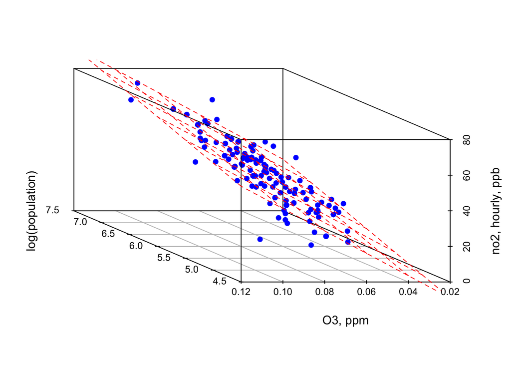

```r
lmPlot <- scatterplot3d(log_pop_2010,o3_8_hr_ppm,no2_1_hr_ppb, xlab = "log(population)", ylab = "O3, ppm", zlab = "no2, hourly, ppb", pch = 16, color = "blue", angle = 330)
lmPlot$plane3d(lmModel1,col = "red")
```

We can estimate that an increase of $10^{population}$ will contribute to $NO_{2}$ hourly measurements by 12.7 ppb and an increase of ozone by 1 ppm will contribute 628 ppb.

The residuals from this model are evenly dispersed and have no particular slant or shape indicative of underlying effects.

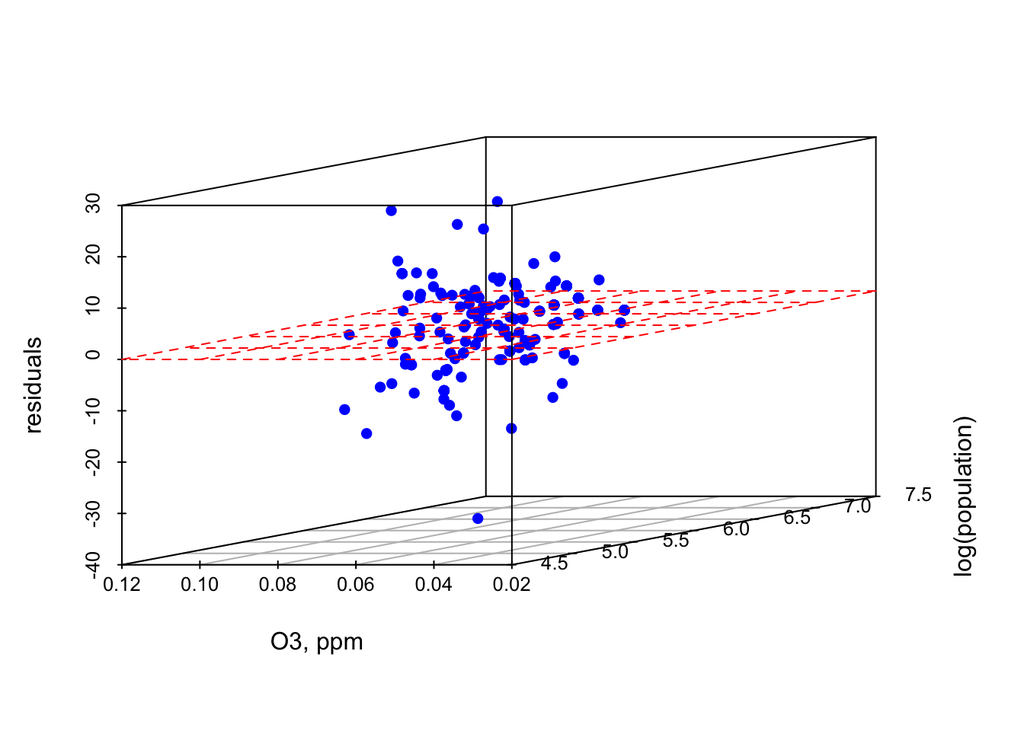

```r
residDF <- df %>% select(log_pop_2010, o3_8_hr_ppm, no2_1_hr_ppb)

residDF <- residDF %>% add_residuals(lmModel1, "resid")

resPlot <- scatterplot3d(x = residDF$log_pop_2010, y = residDF$o3_8_hr_ppm, z = residDF$resid, xlab = "log(population)", ylab = "O3, ppm", zlab = "residuals", pch =16, color = "blue", angle = 200)
resPlot$plane3d(c(0,0,0), col = "red")
```

Using the same model to predict daily $NO_{2}$ measurements produced similar results with $R^{2} = 0.682$.

```r
lmModel12 <- lm(no2_am_ppb ~ log_pop_2010 + o3_8_hr_ppm)
summary(lmModel12)
```

```
##
## Call:
## lm(formula = no2_am_ppb ~ log_pop_2010 + o3_8_hr_ppm)
##
## Residuals:
##     Min      1Q  Median      3Q     Max
## -9.9934 -1.9398 -0.3663  1.2656 15.2702
##
## Coefficients:
##              Estimate Std. Error t value Pr(>|t|)
## (Intercept)  -41.0483     2.2973 -17.868  < 2e-16 ***
## log_pop_2010   6.1625     0.4205  14.654  < 2e-16 ***
## o3_8_hr_ppm  212.8919    30.1304   7.066 1.61e-11 ***
## ---
## Signif. codes:  0 '***' 0.001 '**' 0.01 '*' 0.05 '.' 0.1 ' ' 1
##
## Residual standard error: 3.375 on 248 degrees of freedom
##   (279 observations deleted due to missingness)
## Multiple R-squared:  0.6824, Adjusted R-squared:  0.6798
## F-statistic: 266.4 on 2 and 248 DF,  p-value: < 2.2e-16
```

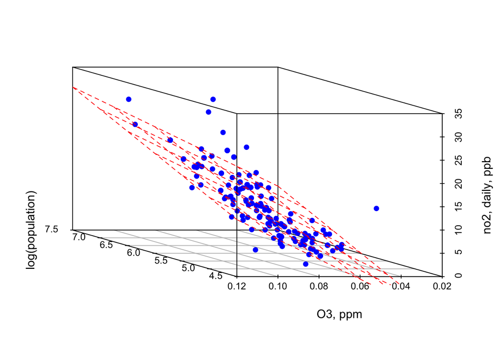

```r
lmPlot <- scatterplot3d(log_pop_2010,o3_8_hr_ppm,no2_am_ppb, xlab = "log(population)", ylab = "O3, ppm", zlab = "no2, daily, ppb", pch = 16, color = "blue", angle = 330)
lmPlot$plane3d(lmModel12,col = "red")
```

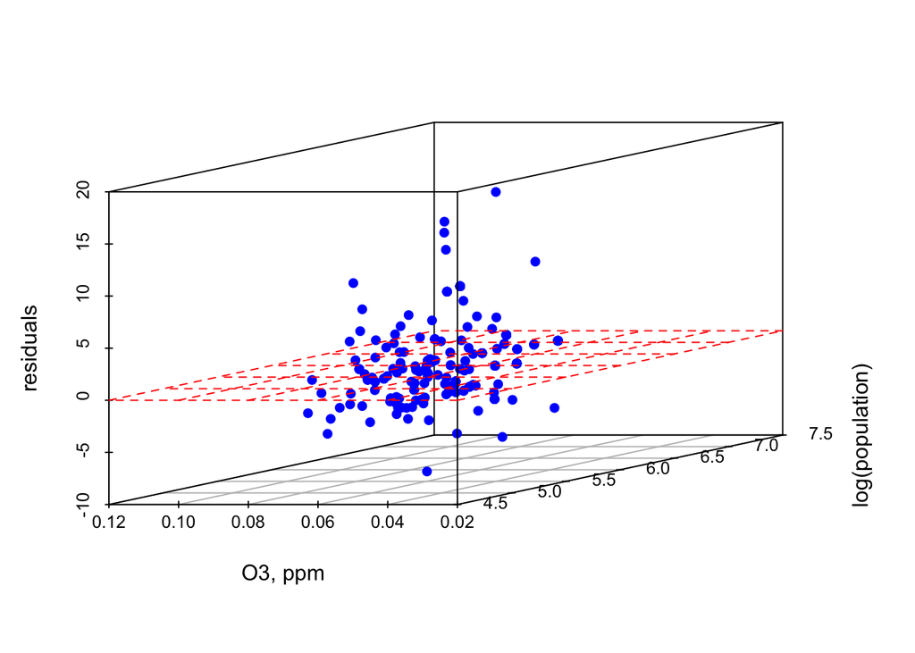

```r
residDF <- df %>% select(log_pop_2010, o3_8_hr_ppm, no2_am_ppb)

residDF <- residDF %>% add_residuals(lmModel12, "resid")

resPlot <- scatterplot3d(x = residDF$log_pop_2010, y = residDF$o3_8_hr_ppm, z = residDF$resid, xlab = "log(population)", ylab = "O3, ppm", zlab = "residuals", pch =16, color = "blue", angle = 200)
resPlot$plane3d(c(0,0,0), col = "red")
```

While the both models have identical predictor terms, the $R^{2}$ value for the daily model is slightly less than that of the hourly. This might have something to do with the nonlinear relationship between the two types of measurements.

```r
lmModel17 <- lm(no2_am_ppb ~ no2_1_hr_ppb + I(no2_1_hr_ppb^2))
summary(lmModel17)
```

```
##
## Call:
## lm(formula = no2_am_ppb ~ no2_1_hr_ppb + I(no2_1_hr_ppb^2))
##
## Residuals:
##     Min      1Q  Median      3Q     Max
## -7.8309 -1.8011 -0.0719  1.1691 10.5767
##
## Coefficients:
##                     Estimate Std. Error t value Pr(>|t|)
## (Intercept)       -1.0263755  1.2301921  -0.834   0.4050
## no2_1_hr_ppb       0.1406429  0.0605830   2.321   0.0211 *
## I(no2_1_hr_ppb^2)  0.0031719  0.0007123   4.453 1.31e-05 ***
## ---
## Signif. codes:  0 '***' 0.001 '**' 0.01 '*' 0.05 '.' 0.1 ' ' 1
##
## Residual standard error: 2.419 on 234 degrees of freedom
##   (293 observations deleted due to missingness)
## Multiple R-squared:  0.8403, Adjusted R-squared:  0.839
## F-statistic: 615.8 on 2 and 234 DF,  p-value: < 2.2e-16
```

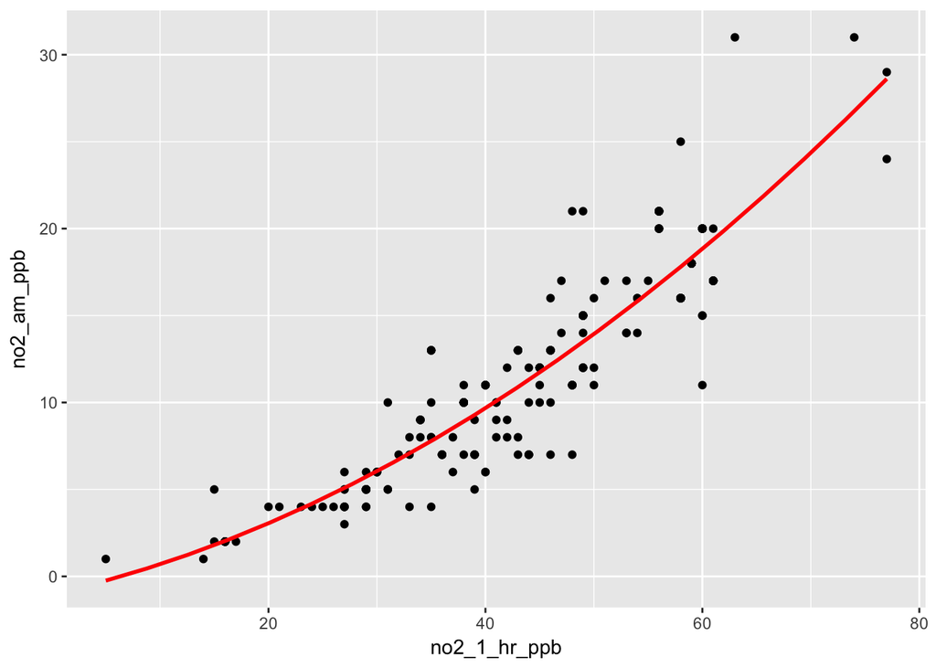

```r
grid4 <- df %>% data_grid(no2_1_hr_ppb = seq_range(no2_1_hr_ppb,20)) %>% add_predictions(lmModel17, "no2_am_ppb")


ggplot(df, mapping=aes(no2_1_hr_ppb, no2_am_ppb)) + geom_point() +  geom_line(data = grid4, col="red", lwd = 1)
```

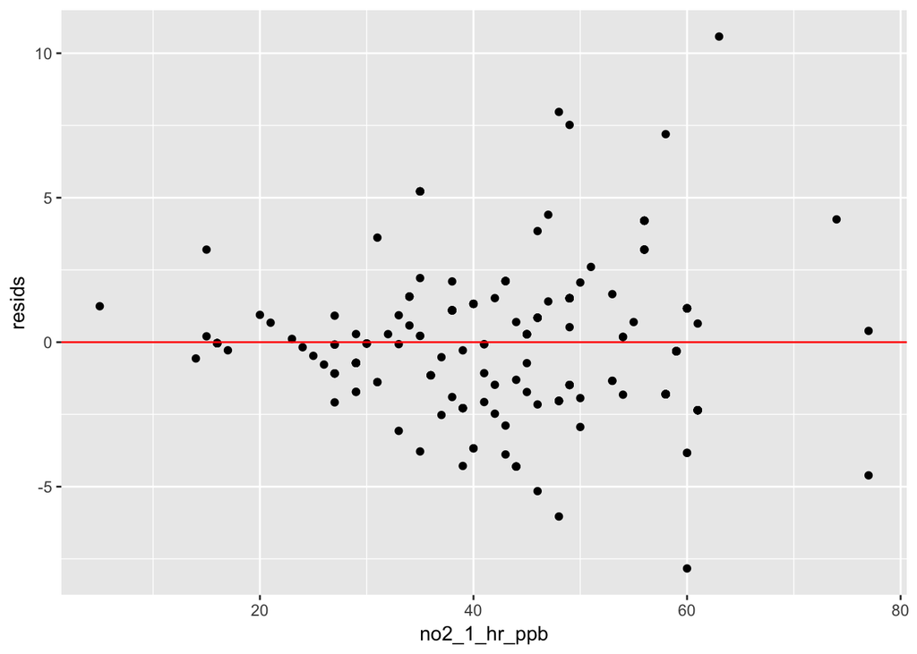

```r
res4 <- df %>% add_residuals(lmModel17,"resids")
ggplot(res4, mapping = aes(no2_1_hr_ppb, resids)) + geom_point() + geom_hline(yintercept = 0, col = "red")
```

The residual plot for this model shows heteroscedasticity so instead we will look at the log transform of the daily measurements.

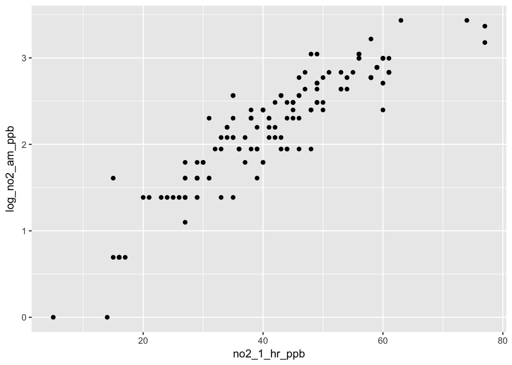

```r
transDf <- df %>% mutate(log_no2_am_ppb = log(no2_am_ppb))
ggplot(transDf, mapping = aes(no2_1_hr_ppb, log_no2_am_ppb)) + geom_point()
```

```r
lmModel17_2 <- lm(log_no2_am_ppb ~ no2_1_hr_ppb + I(no2_1_hr_ppb^2), data = transDf)
summary(lmModel17_2)
```

```
##
## Call:
## lm(formula = log_no2_am_ppb ~ no2_1_hr_ppb + I(no2_1_hr_ppb^2),
##     data = transDf)
##
## Residuals:
##      Min       1Q   Median       3Q      Max
## -0.64570 -0.10983 -0.01767  0.13992  0.88882
##
## Coefficients:
##                     Estimate Std. Error t value Pr(>|t|)
## (Intercept)       -5.207e-01  1.123e-01  -4.635 5.92e-06 ***
## no2_1_hr_ppb       9.116e-02  5.532e-03  16.477  < 2e-16 ***
## I(no2_1_hr_ppb^2) -5.600e-04  6.505e-05  -8.609 1.09e-15 ***
## ---
## Signif. codes:  0 '***' 0.001 '**' 0.01 '*' 0.05 '.' 0.1 ' ' 1
##
## Residual standard error: 0.2209 on 234 degrees of freedom
##   (293 observations deleted due to missingness)
## Multiple R-squared:  0.886,  Adjusted R-squared:  0.885
## F-statistic: 909.3 on 2 and 234 DF,  p-value: < 2.2e-16
```

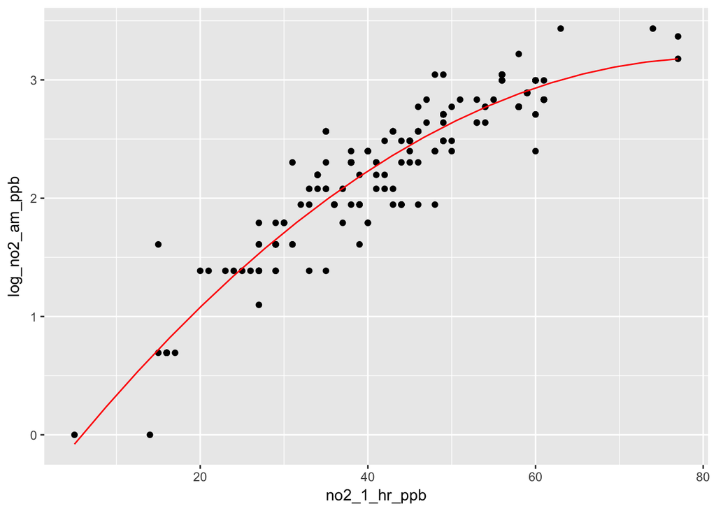

```r
grid5 <- transDf %>% data_grid(no2_1_hr_ppb = seq_range(no2_1_hr_ppb,20)) %>% add_predictions(lmModel17_2, "log_no2_am_ppb")

ggplot(transDf, mapping = aes(no2_1_hr_ppb, log_no2_am_ppb)) + geom_point() + geom_line(data = grid5, col = "red")
```

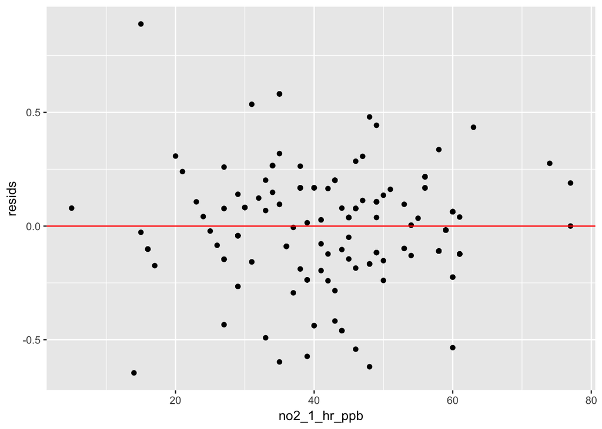

```r
res5 <- transDf %>% add_residuals(lmModel17_2,"resids")
ggplot(res5, mapping = aes(no2_1_hr_ppb, resids)) + geom_point() + geom_hline(yintercept = 0, col = "red")
```